# beatochess no. 11 (June 2025)

Beat Neuenschwander, neuenschwander.beat@gmail.com, https://github.com/beatochess/

# Awards

## Variantim 2024

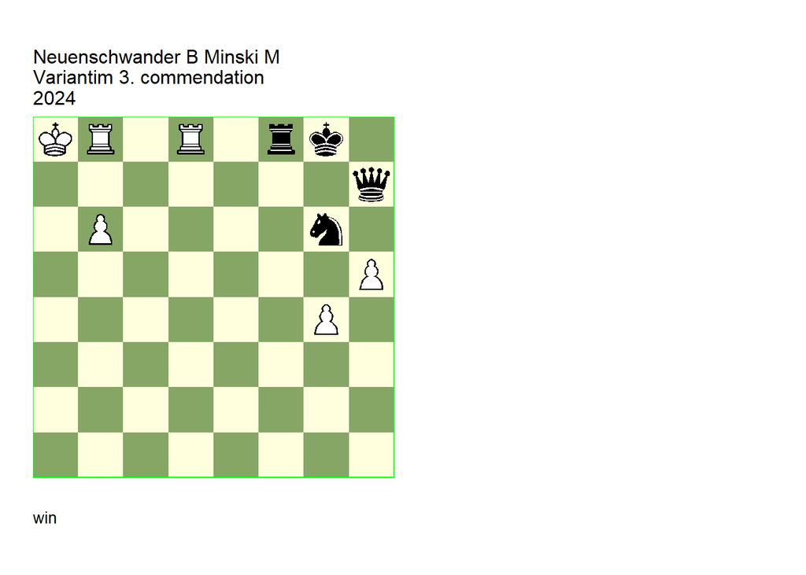

GBR: +3503.30a8g8 FEN: KR1R1rk1/7q/1P4n1/7P/6P1/8/8/8 w - - 0 1

**1. b7** (1. hxg6? Qh1+) (1. Rxf8+? Nxf8 2. b7 Qe4) **1… Qe7** (1… Qf7 **main** 1 2. Rxf8+ Nxf8 3. Rxf8+ Kxf8 (3… Qxf8+ see 3… Qxf8 below ) 4. b8=R+! (4. b8=Q+? thematic try 1 4… Kg7 5. Qb7 Kh8! 6. Qxf7 stalemate 1 ) 4… Kg7 5. Rb7) (1… Qg7 2. Rxf8+ Nxf8 3. Rxf8+ Kh7 (3… Qxf8+ see 3… Qxf8 below ) 4. Rf1!) **2. Rxf8+ Nxf8 3. Rxf8+ Qxf8+** (3… Kxf8 4. b8=R+! **main** 2 (4. b8=Q+? thematic try 2 4… Kg7! 5. Qb7 Kh6! 6. Qxe7 stalemate 2 ) 4… Kf7 5. Rb7) (3… Kh7 4. Rh8+! Kxh8 5. b8=R+!) **4. b8=R!** Triple rook Phoenix to avoid stalemating of black king on h8, h7, and h6 (4. b8=Q? thematic try 3 4… Kh7! 5. Qxf8 stalemate 3 ) **1-0**.

> Daniele Gatti: “My first intention, based on enthusiasm, was to give a prize. But the study has a strong predecessor by P. Arestov [Fide World Cup 2017, 2nd Prize]. The idea is the same: stalemate avoidance of the black King on three different squares thanks to three Rook promotions. However, the matrix, the maneuvers and the thematic stalemate positions are different enough to mark this study as original, at least in its expression if not in its idea. However, considering the quality of the predecessor, I cannot give a higher ranking.”

## Probleemblad 2023/24

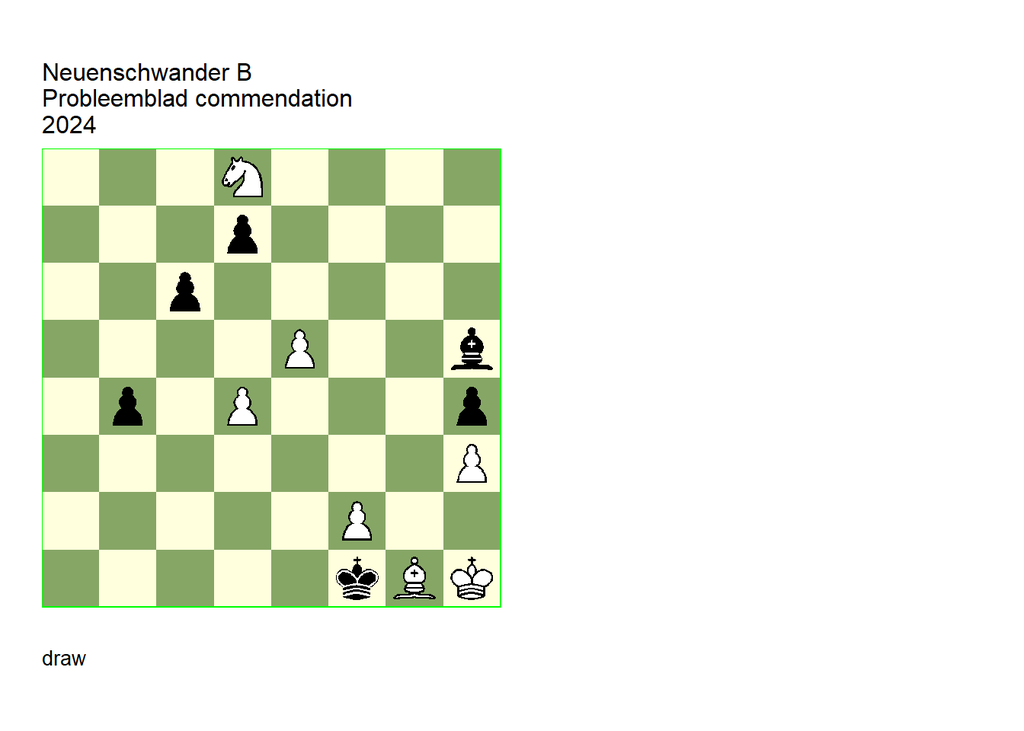

GBR: =0041.44h1f1 FEN: 3N4/3p4/2p5/4P2b/1p1P3p/7P/5P2/5kBK w - - 0 1

**1. Nb7 Bf3+ 2. Kh2 b3** (2… Ke2 3. Nc5 Kd2 (3… Kd1 4. Nxd7 b3 5. Nc5 b2 6. Na4) 4. Nxd7 b3 5. Nb6 =) **3. Na5 b2 4. Nc4 b1=N 5. d5! cxd5 6. e6! dxe6 7. Nd2+ Ke2 8. Nxb1 d4 9. Nd2!** (9. Nc3+? Ke1! -/+) (9. Na3? d3 10. Nc4 e5 -/+) **9… e5 10. Nb3!** (10. Nc4? d3 -/+) **10… Bd5** Tempo! (10… Bc6 11. f4 =) **11. Nc5!** (11. Nc1+? Kd2 12. f4 Kxc1 13. fxe5 d3 14. Be3+ d2 15. Kg1 Kc2 -/+) **11… e4 12. Nd7!** (12. f3? e3! -/+) **12… d3 13. Nf6!** Tempo! **13… Bc6 14. Ng4 d2 15. Ne3** This successfully ends the tour of the busy knight. **1/2-1/2**.

Gady Costeff: “The white knight gallops all over the board, first stopping one pawn from queening, and then another. The study would be improved if Bg1 arrived ther during play.”

## Magyar Sakkvilag 2024

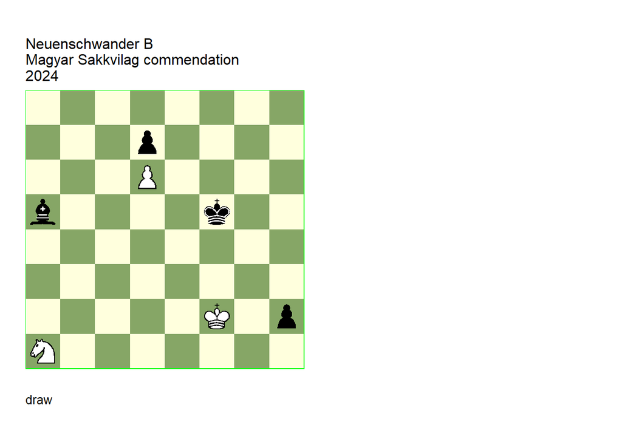

GBR: =0031.12f2f5 FEN: 8/3p4/3P4/b4k2/8/8/5K1p/N7 w - - 0 1

**1. Kg2 Bb6!** Prepares the defence of the h-pawn. (1… Ke4 2. Nb3! Bb4 ( 2… Bb6 3. Nd2+ = (3. Kxh2? Kd3) ) 3. Kxh2 =) (1… Ke4) **2. Nb3!** ( After 2. Kxh2? , the white knight cannot be saved. 2… Ke4 3. Nc2 Ba5 4. Na3 Kd3 5. Kg2 Bb4 6. Nb5 Kc4 7. Nc7 (7. Na7 Bxd6 8. Nc8 Bc5 -+) 7… Bxd6 8. Ne8 Be5 -+) **2… Bg1 3. Nc1!** (3. Na5? Ke5 4. Nb7 Kd5 -+) **3… Ke5 4. Na2! Ke6!** Sets up a trap. **5. Kh1!** (5. Nb4? is premature because of 5… Bc5! -+) **5… Kxd6 6. Nb4! Ke6** (6… Kc5 7. Na6+! Kc4 8. Nb8! ( 8. Nc7 Bd4 -+) 8… d5 9. Nd7 d4 10. Ne5+ =) **7. Na6!** (7. Kg2? Bc5 -+) **7… Bd4!** (7… Kd5 8. Nb8 d6 9. Nd7 =) **8. Kg2!** (8. Kxh2? Be5+! 9. Kg2 Bd6! -+) **8… Kd5 9. Nb8! d6 10. Kxh2** Finally. **10… Ba7 11. Na6!** (11. Nd7? Ke6 12. Nf8+ Kf7 =) **1/2-1/2**.

> Jan Sprenger: “Precise and logical play, and instructive for practical players, but I do not discern enough of really artistic idea to merit more than a commendation.”

# Comments and revisions

## Prize winners

### Dobrescu & Nestorescu =4536.41g4g7 (1986). Cook, (partial) correction

Date: June 30, 2025

File: Dobrescu1986c.pgn

Unfortunately the second part (moving backwards) of the systematic manoeuvre does not work due to **12. Qe5+!**.

The correction rectifies this. However, after **13… Qf8** at the end, White draws with **14. Rb8** as well as **14. Rc7**. That is, the pendulum swings forth and back only once, I could not find a correction with **14. Rb8** as the only drawing move.

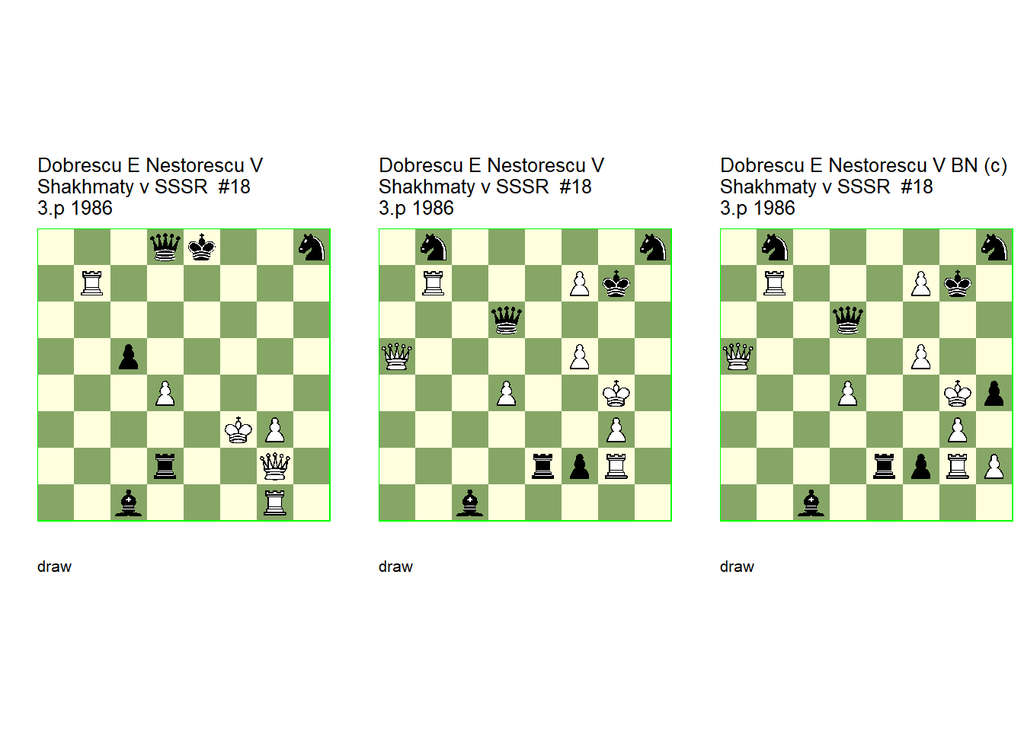

GBR: =4533.21f3e8 (c) U2 FEN: 3qk2n/1R6/8/2p5/3P4/5KP1/3r2Q1/2b3R1 w - - 0 1

Shakhmaty v SSSR/6 (EG#07398). correction: Dobrescu=E Nestorescu=V Shakhmaty v SSSR/4 1987. U2: Van, der, Heijden=H EBUR=2 6/1998. **1. Re1+! Kf8 2. Qf1! Qf6+** (2… Nf7 3. Rxf7+ Kxf7 4. Re4! Rc2 5. Kg4+) **3. Kg4 Rf2 4. Re8+! Kxe8 5. Qb5+ Kf8 6. Qxc5+ Kg8 7. Qc8+** (7. Qd5+? Nf7!) **7… Qf8 8. Rb8!** (8. Rc7! **cook** HH 8… Re2 (8… Ba3 9. Qe6+ Nf7 10. Rc8) 9. Qxf8+ Kxf8 10. Rxc1) (8. Qc4+? Nf7 9. Qxc1 Qg7+ 10. Kh3 Qh7+) **8… Kg7** (8… Qxc8+ 9. Rxc8+ Kf7 10. Rxc1) (8… Nf7 9. Qc7) (8… Rf7 9. Kh5 Rh7+ 10. Kg4 Rf7 11. Kh5 Rf5+ 12. Kg4 Kg7 13. Qxc1 Qf6 14. Rg8+ Kxg8 15. Qc8+) **9. Qc7+!** (9. Rb7+? Nf7 10. Qxc1 Qg8! 11. Qc6 Kh8+ 12. Kh3 Qh7+) **9… Qf7 10. Rb7! Kg6** (10… Ng6 11. Qb8! Ne7 12. Qe5+ Kg6 13. Qh5+ Kg7 14. Qe5+ Kg6 15. Qh5+) **11. Qc6+!** (11. Rb6+? Kh7 12. Rb7 Ba3 13. Qc6 Be7 14. Qe4+ Ng6) **11… Qf6 12. Rb6!** (12. Qe4+? Qf5+!) (12. Qe8+? Nf7 13. Qg8+ Kh6) **12… Kg7 13. Qc7+ Qf7 14. Rb7 Kg8 15. Qc8+ Qf8 16. Rb8 1/2-1/2**.

GBR: =4536.41g4g7 (c) U2 FEN: 1n5n/1R3Pk1/3q4/Q4P2/3P2K1/6P1/4rpR1/2b5 w - - 0 1

Shakhmaty v SSSR/6. correction: Nestorescu=V EG=193 7/2013. U2: Neuenschwander=B beatochess 30/06/2025. **1. f6+! Qxf6** (1… Kf8 2. Rxf2! Re3 (2… Rxf2 3. Rxb8+ Qxb8 4. Qc5+) 3. Rxb8+! Qxb8 4. Qc5+ Kxf7 5. Qd5+ Kf8 6. Qc5+ Ke8 7. Qc6+ Kf8 8. Qc5+) **2. f8=Q+!** (2. Rxf2? Qg6+ 3. Kh3 Qh6+ 4. Kg4 Re4+ 5. Kf3 Qh1+ 6. Rg2 Qf1+ 7. Rf2 Re3+ 8. Kg4 Qd1+ 9. Kh3 Qh1+ 10. Rh2 Qxb7) **2… Kxf8 3. Rxf2 Rxf2 4. Qc5+ Kg8 5. Qc8+ Qf8 6. Rxb8** (6. Qc4+? Nf7 7. Qxc1 Qg7+ 8. Kh3 Qh7+ 9. Kg4 Qf5+) (6. Rc7? Rd2! 7. Qe6+ (7. Qxf8+ Kxf8 8. Rxc1 Rxd4+) 7… Nf7 8. Qg6+ Kh8 9. Rxf7 Rxd4+ 10. Kh5 Qc5+ 11. Rf5 Qe7) **6… Kg7** (6… Rf7 7. Kh5! Rh7+ 8. Kg4 Rf7 9. Kh5 Rh7+ 10. Kg4) **7. Qc7+!** (7. Rb7+? Nf7 8. Qxc1 Qg8 9. Qc6 Kh8+ 10. Kh3 Qh7+ 11. Kg4 Nh6+) **7… Qf7 8. Rb7! Kg6** (8… Kf6 9. Qb8) (8… Ng6 9. Qb8 Ne7 10. Qe5+ Kg6 11. Qh5+ Kg7 12. Qe5+ Kg6 13. Qh5+) **9. Qc6+** (9. Rb6+? Kh7! 10. Rb7 Ba3! 11. Qc6 Be7 12. Qe4+ Ng6) **9… Qf6 10. Rb6!** (10. Qe4+? Qf5+!) (10. Qe8+? Nf7 11. Qg8+ Kh6) **10… Kg7 11. Qc7+ Qf7 12. Rb7** (12. Qe5+! **cook** **BN** 12… Rf6 13. Rxf6 Qxf6 14. Qc7+) **12… Kg8 13. Qc8+ Qf8 14. Rb8 1/2-1/2**.

GBR: =4536.52g4g7 (c) FEN: 1n5n/1R3Pk1/3q4/Q4P2/3P2Kp/6P1/4rpRP/2b5 w - - 0 1

correction: Neuenschwander=B beatochess 30/06/2025. **1. f6+ Qxf6** (1… Kf8 2. Rxf2) **2. f8=Q+ Kxf8 3. Rxf2 Rxf2 4. Qc5+ Kg8 5. Qc8+ Qf8 6. Rxb8 Kg7 7. Qc7+ Qf7** (7… Rf7 8. Qe5+) **8. Rb7 Kg6** (8… Qxc7 9. Rxc7+ Nf7 10. Rxc1) **9. Qc6+ Qf6 10. Rb6 Kg7 11. Qc7+ Qf7 12. Rb7 Kg8 13. Qc8+ 1/2-1/2**.

### Rumyantsev =0700.31h6c3 (1986). Correction

File: Rumyantsev1986a.pgn

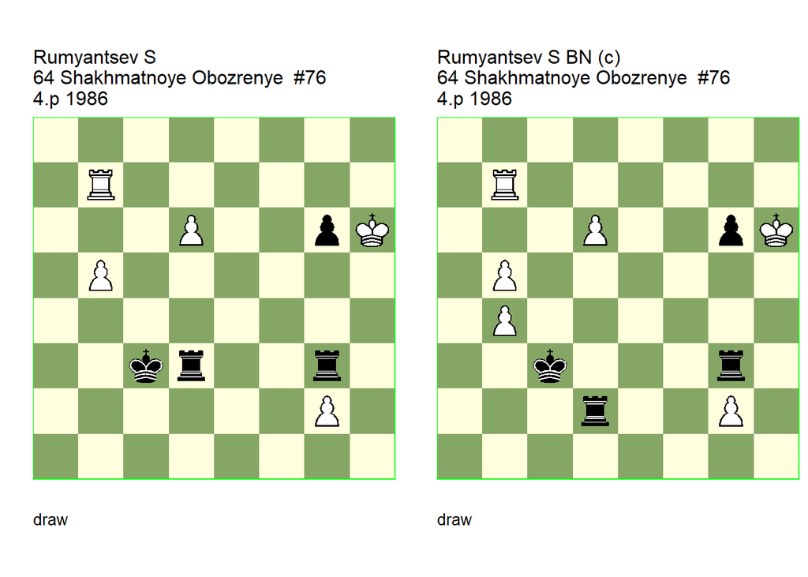

GBR: =0700.31h6c3 U1 FEN: 8/1R6/3P2pK/1P6/8/2kr2r1/6P1/8 w - - 0 1

64 Shakhmatnoye Obozrenye=19(763) 64 Shakhmatnoye Obozrenye/10 (EG#07329). U1: Garcia=M HHdbIV#54575 19-1-2007. **1. Rc7+** (1. d7! **cook** MG 1… Rxg2 2. Rc7+ Kb4 3. b6 Rh2+ 4. Kg5 Rd5+ 5. Kxg6 Rg2+ 6. Kf6 Rf2+ 7. Ke7) **1… Kb4 2. b6 Rxd6 3. b7 Rb6** (3… g5+ **main** 4. Kh5! Rb6 5. Rc6! Rb5 6. b8=Q Rxb8 7. Rb6+! Rxb6) **4. b8=Q Rxb8 5. Rb7+! Rxb7 1/2-1/2**.

GBR: =0700.41h6c3 (c) FEN: 8/1R6/3P2pK/1P6/1P6/2k3r1/3r2P1/8 w - - 0 1

correction: Neuenschwander=B beatochess 30/06/2025. **1. Rc7+** (1. d7? Kxb4) **1… Kxb4 2. b6 Rxd6 3. b7 Rb6** (3… g5+ **main** 4. Kh5 Rb6 5. Rc6 Rb5 6. b8=Q Rxb8 7. Rb6+ Rxb6) **4. b8=Q Rxb8 5. Rb7+ Rxb7 1/2-1/2**.

### Umnov +0402.01a5f1 (1985). Cook

Date: June 30, 2025

File: Umnov1985a.pgn

**4. Nb3!** cooks the study.

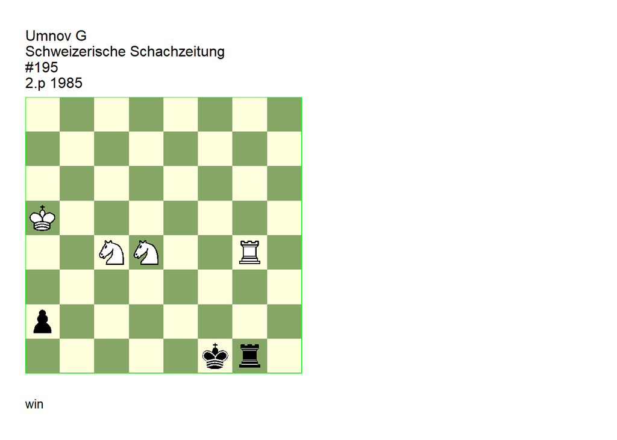

GBR: +0402.01a5f1 FEN: 8/8/8/K7/2NN2R1/8/p7/5kr1 w - - 0 1

Schweizerische Schachzeitung=11 Schweizerische Schachzeitung/11 (EG#07359). U2: Neuenschwander=B beatochess 30/06/2025. **1. Nd2+** (1. Rf4+? Kg2 2. Ne3+ Kh3 3. Rf3+ Kh4) **1… Kf2 2. Ne4+ Kf1 3. Rf4+ Ke1 4. Kb4** (4. Nf3+? Kd1 5. Nf2+ (5. Nc3+ Kc2 6. Nxa2 Ra1 7. Ra4 Kb2) 5… Kc2 6. Rc4+ Kb3 7. Nd2+ Ka3 8. Rc3+ Kb2 9. Kb4 Rg4+ 10. Nxg4 a1=Q) (4. Nc2+? Ke2 5. Rf2+ Kd3 6. Nc5+ Kc4) (4. Nb3? Ke2 5. Nc3+ Ke3 6. Nd5+ Kd3 7. Ra4 Kc2) (4. Nb3! **cook** **BN** 4… Ke2 5. Nc3+ Ke3 6. Ra4 +-) **4… a1=Q** (4… a1=N 5. Nf3+) (4… Kd1 5. Nc3+ Kd2 6. Nxa2) (4… Rg2 5. Nb3 Rb2 6. Rh4 Rb1 7. Rh1+ Ke2 8. Nc3+) (4… Rg8 5. Nc2+ Kd1 6. Na1 Kc1 7. Nb3+) **5. Nc2+ Ke2 6. Rf2+ Kd3** (6… Kd1 7. Rd2+ Kc1 8. Nxa1) **7. Nc5# 1-0**.

Date: June 30, 2025

File: Kozirev1986a.pgn

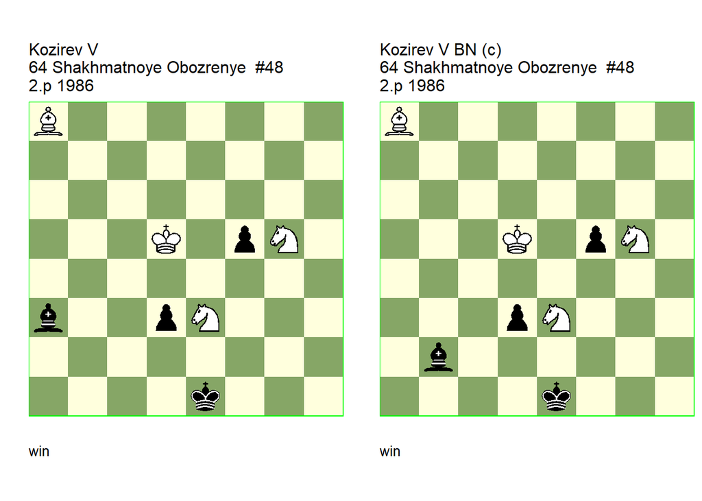

GBR: +0042.02d5e1 U1 FEN: B7/8/8/3K1pN1/8/b2pN3/8/4k3 w - - 0 1

64 Shakhmatnoye Obozrenye=12(755) 64 Shakhmatnoye Obozrenye/6 9/20.p USSR overall champ XVIII 1985-1986 Bulletin Central Chess Club USSR=19(461) Bulletin Central Chess Club USSR/7 1989 (EG#07327). U1: Garcia=M HHdbV#27299 24-9-2011 U1: Afek=Y HHdbVI 6-8-2020. **1. Kc4!** (1. Ke5! **cook** MG 1… Bc1 2. Nf3+ Ke2 3. Nxf5 d2 4. N3d4+ Ke1 5. Nc2+ Kf2 6. Nce3 Ke2 7. Kf4 Ke1 8. Bf3) (1. Kd4! **cook** YA 1… Bc1 2. Ng2+ Kf2 3. Ne6 d2 4. Ne3 Ke2 5. Nf4+) **1… Bc1!** ( 1… d2 2. Bf3 Be7 3. Nh3!) **2. Nf3+** (2. Kxd3? Kf2 3. Nd1+ Ke1 4. Ne3 Kf2 5. Nh3+ Kg3 6. Ng1 Kf2 7. Nh3+ Kg3 8. Ng5 Kf2) **2… Ke2 3. Nxf5! d2 4. N3d4+ Ke1 5. Nc2+ Kf2! 6. Nfe3 Ke2 7. Kc3 d1=Q 8. Nxd1 Bd2+** (8… Kxd1 9. Bf3#) **9. Kb2 Kxd1 10. Bf3# 1-0**.

GBR: +0042.02d5e1 (c) FEN: B7/8/8/3K1pN1/8/3pN3/1b6/4k3 w - - 0 1

correction: Neuenschwander=B beatochess 30/06/2025. **1. Kc4 Bc1!** (1… d2 2. Bf3 Bf6 3. Nh3) **2. Nf3+** (2. Kxd3? Kf2 3. Nd1+ Ke1 4. Ne3 Kf2 5. Nh3+ Kg3 6. Ng1 Kf2 7. Nh3+ Kg3 8. Ng5 Kf2) **2… Ke2 3. Nxf5! d2 4. N3d4+ Ke1 5. Nc2+ Kf2! 6. Nfe3 Ke2 7. Kc3 d1=Q 8. Nxd1 Bd2+** (8… Kxd1 9. Bf3#) **9. Kb2 Kxd1 10. Bf3# 1-0**.

### Lommer =0430.11b8g1 (1963). Cook

Date: June 17, 2025

File: Lommer1963a.pgn

**9. Rh7!** cooks the correction.

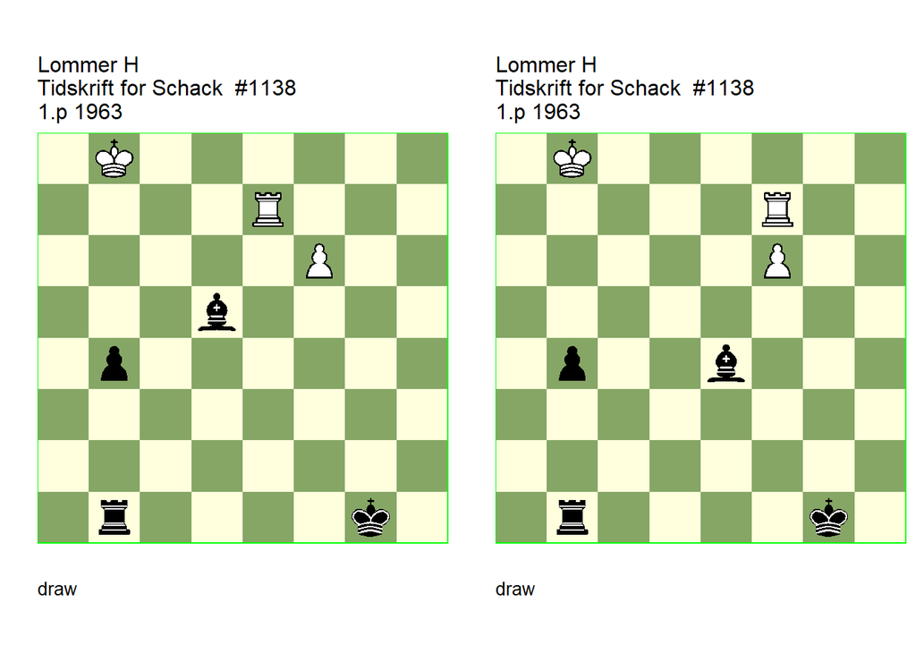

GBR: =0430.11b8g1 (c) U2 FEN: 1K6/4R3/5P2/3b4/1p6/8/8/1r4k1 w - - 0 1

Tidskrift for Schack=9 Tidskrift for Schack/11. U2: Neuenschwander=B beatochess 17/06/2025. **1. Rd7! Be6** (1… Bc6 2. f7 Rf1 3. Rd1!) (1… Rd1 2. f7!) **2. Re7 Bc4 3. Re4** (3. f7? Rf1 4. Re4 Rxf7 5. Rxc4 b3) (3. Rc7? Ba2 4. Ra7 b3 5. f7 Rf1) **3… Ba2** (3… Rc1 4. f7) **4. Re2** (4. Ka7? Bf7 5. Re7 b3) (4. Kc7? Bf7 5. Re7 Bc4 6. Re4 Rc1) **4… Bb3 5. Re4** (5. Re3? Kf2!) **5… Ba2 6. Re2 Bg8!** (6… Ra1 7. Re4 b3 8. f7 b2 9. f8=Q b1=Q+ 10. Qb4) **7. Re8 Bf7 8. Re7 Bh5 9. Re5** (9. Rh7? Bf3! 10. f7 Ra1 11. Kc7 Ra8) (9. Rh7! **cook** **BN** 9… Bf3 10. f7 Ra1 11. Kc7 Ra8 12. Kd6) **9… Bf7** (9… Bg6 10. Rg5+) (9… Bf3 10. f7 Ra1 11. Rf5) **10. Re7 Bd5 11. Rd7** (11. Re5? Rd1) **11… Bc4 12. Rd4 Bf7 13. Rd7 Bh5 14. Rd5 Be2** (14… Bf3 15. Rd3 Rf1 16. Rb3) **15. Rd2 Bc4 16. Rd4 Bf7 17. Rd7 Bb3 18. Rd4** (18. f7? Bxf7 19. Rxf7 b3 20. Rf5 (20. Rf4 Rd1) 20… Rc1! (20… Rd1? 21. Rb5 Rd3 22. Kb7 Kf2 23. Kb6 Ke2 24. Ka5 Kd2 25. Ka4 Kc2 26. Ka3 Rc3 27. Rb4 Rc8 28. Rc4+! Rxc4) 21. Rb5 Rc3 22. Kb7 Kf2 23. Kb6 Ke2 24. Ka5 Kd2 25. Ka4 Kc2 26. Ka3 Rc8) **1/2-1/2**.

GBR: =0430.11b8g1 U1 FEN: 1K6/5R2/5P2/8/1p2b3/8/8/1r4k1 w - - 0 1

Tidskrift for Schack=11 Tidskrift for Schack/9 (EG#00037). U1: Veitch=W EG=3 1/1966. **1. Re7** (1. Rg7+ Kh1 (1… Kf1? 2. f7) (1… Bg2 2. f7 (2. Rg3! **cook** WV 2… Kh2 3. f7) ) (1… Kh2 2. f7 Rf1 3. Rg4 b3 4. Rxe4 b2 5. Re2+ ) 2. Rg4! **cook** WV (2. Re7 Bd5 3. f7 Bxf7 (3… Rf1 4. Re1) 4. Rxf7 b3 5. Rf5) 2… Bd5 3. Rh4+ Kg1 4. Rd4 Ba2 5. Rd2) (1. Rd7? b3 2. Rd4 b2 3. Rxe4 Rf1 4. Rb4 b1=Q 5. Rxb1 Rxb1+ 6. Kc7 Rf1) **1… Bd5** (1… Bg6 2. Rg7 Rf1 3. Rxg6+) **2. Rd7 Be6 3. Re7 Bc4 4. Re4** (4. f7? Rf1 5. Re4 Rxf7 6. Rxc4 b3) **4… Ba2** (4… Rc1 5. f7) **5. Re2** (5. Ka7? Bf7 6. Re7 b3) (5. Kc7? Bf7 6. Re7 Bc4 7. Re4 Rc1) **5… Bb3 6. Re4** (6. Re3? Kf2) **6… Ba2 7. Re2 Bg8** (7… Ra1 8. Re4 b3 9. f7 b2 10. f8=Q b1=Q+ 11. Qb4) **8. Re8 Bf7 9. Re7 Bh5 10. Re5 Bf7 11. Re7 Bd5 12. Rd7 Bc4 13. Rd4 Bf7 14. Rd7 Bh5 15. Rd5 Be2** (15… Bf3 16. Rd3 Rf1 17. Rb3) **16. Rd2 Bc4 17. Rd4 Bf7 18. Rd7 Bb3 19. Rd4** (19. f7? Bxf7 20. Rxf7 b3! 21. Rf5 Rc1 22. Rb5 Rc3 23. Kb7 Kf2 24. Kb6 Ke2 25. Ka5 Kd2 26. Ka4 Kc2 27. Ka3 Rc6) **1/2-1/2**.

### Myllyniemi =0413.01a1h2 (1965). Minor dual

Date: June 16, 2025

File: Myllyniemi1965a.pgn

There is a minor dual in the second mainline, **8… Kd4 9. Rd7+!**.

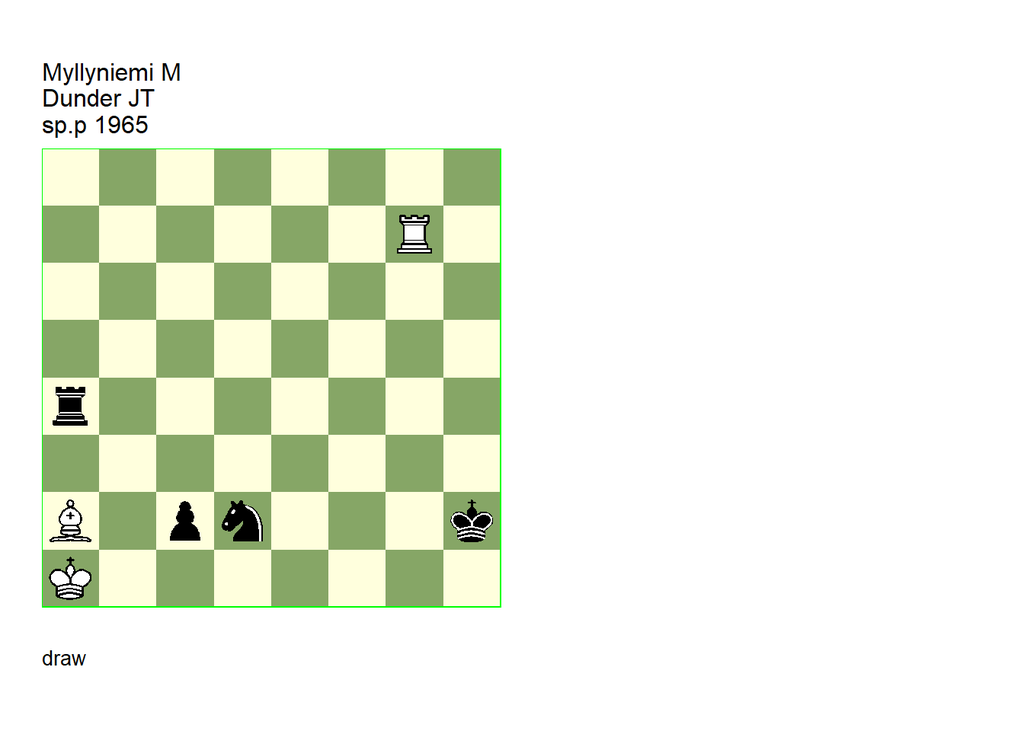

GBR: =0413.01a1h2 (U2) FEN: 8/6R1/8/8/r7/8/B1pn3k/K7 w - - 0 1

(EG#00015). (U2): Neuenschwander=B beatochess 16/06/2025. **1. Kb2!** (1. Rh7+? Kg2 2. Kb2 (2. Rc7 Rc4! (2… c1=Q+? 3. Rxc1 Nb3+ 4. Kb2 Nxc1 5. Bd5+ Kf2 6. Kxc1) (2… Nc4? 3. Rg7+ Kf3 4. Rg3+ (4. Rg1? Ne3 5. Rc1 Ke2 6. Kb2 Kd2 7. Bb3 Rb4) 4… Ke4 (4… Kxg3) (4… Ke2 5. Rg2+ Kd3 6. Rxc2 Kxc2) 5. Rc3 Ne3 (5… Na3 6. Bb3) 6. Kb2 Nd1+ 7. Kxc2 Nxc3 8. Bb3) ) 2… Rxa2+ 3. Kxa2 c1=Q 4. Rh2+ Kf3 5. Rh3+ Kf2 6. Rh2+ Ke3 7. Re2+ Kd4) (1. Rc7? Rc4!) **1… Rxa2+ 2. Kxa2 Nc4!** (2… c1=Q **main** 3. Rg2+ Kxg2) **3. Rh7+ Kg2 4. Rg7+ Kf2 5. Rf7+ Ke2 6. Re7+ Kd2 7. Rd7+ Kc3 8. Rc7!** (8. Rd1? cxd1=B! (8… cxd1=Q?) ) **8… c1=Q** (8… Kd4 **main** 9. Rxc4+ (9. Rd7+? Kc5 10. Rc7+ Kd5 11. Rd7+ Kc6 12. Rd1 cxd1=B! (12… cxd1=Q?) ) (9. Rd7+ minor **dual** **BN** 9… Kc5 10. Rc7+ Kd5 11. Rxc4!) 9… Kxc4 10. Kb2 Kd3 11. Kc1 Kc3) **9. Rxc4+ Kxc4 1/2-1/2**.

Date: June 16, 2025

File: Kivi1965a.pgn

**2. Be6!** cooks the study.

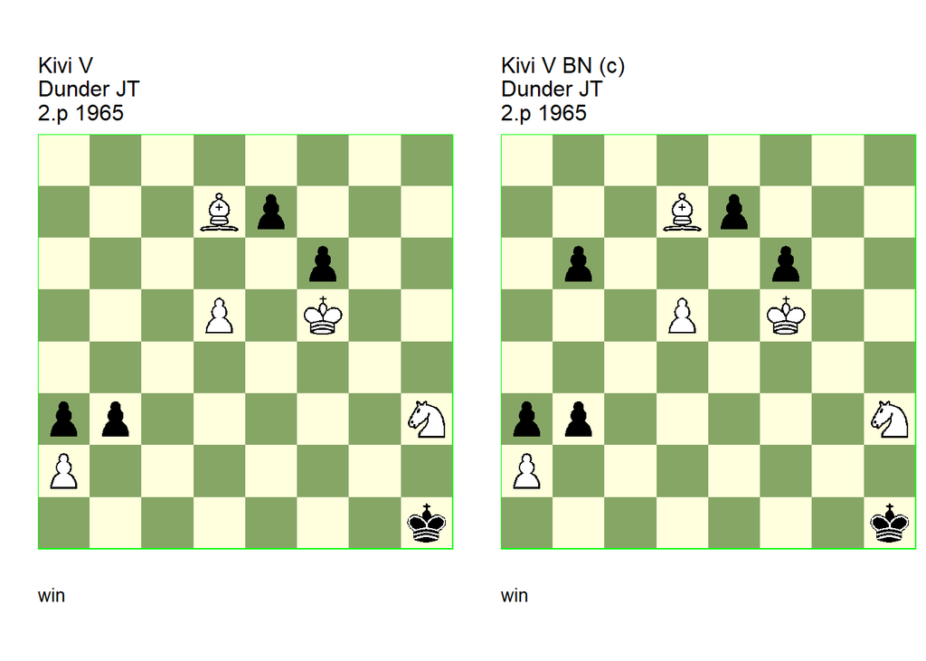

GBR: +0011.24f5h1 U2 FEN: 8/3Bp3/5p2/3P1K2/8/pp5N/P7/7k w - - 0 1

(EG#00011). U2: Neuenschwander=B beatochess 16/06/2025. **1. d6!** (1. Bc6? bxa2 2. d6+ Kh2 3. d7 a1=Q 4. d8=Q Qe5+ 5. Kg6 Qg3+) **1… exd6** (1… bxa2 2. dxe7 a1=Q 3. e8=Q Qf1+ 4. Kg4 Qc4+ 5. Kg3 Qd3+ 6. Kh4 Qh7+ 7. Kg4 Qg7+ 8. Kf4 Qh6+ 9. Kf3) **2. Kg4!** (2. Be6! **cook** **BN** 2… b2 3. Bd5+ Kh2 4. Be4 Kxh3 5. Kxf6 Kg3 6. Ke6 Kf4 7. Bh7 Ke3 8. Kxd6) **2… Kh2** (2… Kg2 3. Bc6+ Kf1 4. Bd5 bxa2 (4… b2 5. Be4 d5 6. Bf5 Ke1 7. Nf4 d4 8. Ne6! d3 9. Bxd3 Kd2 10. Nc5 Kc1 11. Nb3+) 5. Bxa2 Ke1 6. Nf4 Kd2 7. Kf5 Kc1 8. Bg8 Kb2 9. Nd3+ Kb1 10. Nb4) **3. Be6 f5+!** (3… b2 4. Bf5 Kg2 5. Nf4+ Kf2 6. Nd5 Ke2 7. Nc3+ Kd2 8. Nb5 Kc1 9. Nxa3) **4. Kh4 d5! 5. Bxd5 b2 6. Ng5! b1=Q 7. Nf3+ Kg2** (7… Kh1 8. Nd2+) **8. Nd2+ 1-0**.

GBR: +0011.25f5h1 (c) FEN: 8/3Bp3/1p3p2/3P1K2/8/pp5N/P7/7k w - - 0 1

correction: Neuenschwander=B beatochess 16/06/2025. **1. d6 exd6 2. Kg4 Kh2 3. Be6 f5+ 4. Kh4 d5 5. Bxd5 b2 6. Ng5 b1=Q 7. Nf3+ Kg2 8. Nd2+ 1-0**.

Date: June 16, 2025

File: Bron1964a.pgn

Timman’s correction is correct, but the one by Osintsev is not due to **3… f4!**.

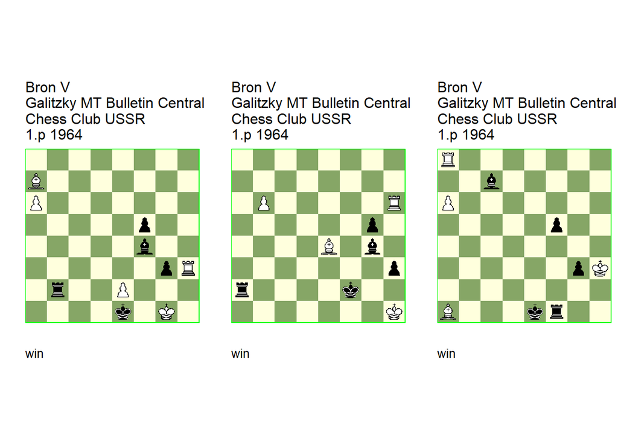

GBR: +0440.22g1e1 U2 U3 FEN: 8/B7/P7/5p2/5b2/6pR/1r2P3/4k1K1 w - - 0 1

Bulletin Central Chess Club USSR=6(36) Bulletin Central Chess Club USSR/6 3.p USSR overall champ VII 1962-1964 (EG#00007). U2 U3: Garcia=M HHdbIV#33709 19-1-2007. **1. Bd4!** (1. Bc5? Bb8 2. e3 Rh2 3. Rxh2 gxh2+ 4. Kg2 Ke2 5. a7 Bxa7 6. Bxa7 h1=Q+ 7. Kxh1 Kf3) **1… Ra2! 2. a7 Kxe2! 3. Rh8 Be5!** (3… Kd3! **cook** MG 4. Bc5 Kc4 5. Rc8 Bg5 6. Bb6+ (6. Kf1 Kb5 7. Bg1 g2+ 8. Ke1 Bh4+ 9. Kd1 f4 10. a8=Q Rxa8 11. Rxa8 f3) 6… Kb5 7. Bd4 Bf6 8. Rb8+ Kc6) **4. Re8! Kd3 5. Bc5!** (5. Bb6? Bc7 6. Bc5 Kc4 7. Be3 f4 8. a8=Q Rxa8 9. Rxa8 fxe3 10. Rc8 e2 11. Rxc7+ Kd3) **5… Bd6! 6. Rd8!** (6. Re3+? Kc4 7. Ba3 Bc5! 8. a8=Q Bxe3+ 9. Kf1 g2+ 10. Qxg2 Rxg2) **6… Kc4 7. Bb6!** (7. Be3! **cook** MG 7… f4 (7… Ra1+ 8. Kg2 Ra2+ 9. Kf3 f4 10. Bb6 Ra3+ 11. Ke4) 8. Rc8+ Kd5 9. Bb6 Ra1+ 10. Kg2 Ra2+ 11. Kh3 f3 12. a8=Q+ Rxa8 13. Rxa8 Ke4 14. Ra4+) **7… Bc7! 8. Rc8! Kb5 9. Bd4!** (9. Be3? f4 10. Bd4 Kc4) **9… Kc4!** (9… Be5 10. Rc5+) **10. Be3! Kd3** (10… f4 11. Rxc7+) **11. Bc5! Ra1+** (11… Bd6 12. Bb6) **12. Kg2 Ra2+ 13. Kf3 Rf2+! 14. Bxf2 gxf2 15. Kg2! Ke2 16. Re8+ 1-0**.

GBR: +0440.12h1f2 (c) FEN: 8/8/1P5R/6p1/4B1b1/7p/r4k2/7K w - - 0 1

Bulletin Central Chess Club USSR=6(36) Bulletin Central Chess Club USSR/6 3.p USSR overall champ VII 1962-1964. correction: Timman=J The Art of the Endgame-216 2011. **1. b7 Rb2 2. Rh8 Bf5** (2… Ke3 3. Bd5 Kd4 4. Rd8) **3. Rf8 Ke3 4. Bd5! Be6 5. Re8! Kd4 6. Bc6!** (6. Bf3? g4) **6… Bd7 7. Rd8! Kc5 8. Be4! Kd4** (8… Bf5 9. Rd5+) **9. Bf3 Ke3 10. Bd5 Be6 11. Bc6 Rb1+ 12. Kh2 Rb2+ 13. Kg3 1-0**.

GBR: +0440.12h3e1 (c) U3 FEN: R7/2b5/P7/5p2/8/6pK/8/B3kr2 w - - 0 1

Bulletin Central Chess Club USSR=6(36) Bulletin Central Chess Club USSR/6. correction: Osintsev=S Grossmeister Bron - Zadachy i Etyudi#338a 2017. U3: Neuenschwander=B beatochess 16/06/2025. **1. Bd4!** (1. Re8+? Kd2 2. Bd4 Kd3 3. a7 Rh1+ 4. Kg2 Rh2+ 5. Kg1 Ra2 6. Bc5 Kc4) **1… Rh1+ 2. Kg2 Rh2+ 3. Kg1 Ra2** (3… f4! **cook** **BN** 4. Re8+ Re2) **4. a7 Ke2! 5. Rc8** (5. Rf8? Kd3! 6. Bc5 Kc4 7. Rxf5 Ra4! (7… Kb5? 8. Ba3+!) 8. Kg2 Kb5) **5… Be5! 6. Re8!** (6. Bb6? Ra1+! 7. Kg2 f4! 8. Rc2+ Kd3 9. Rc5 Ke4! 10. Ra5 f3+ 11. Kh3 Rh1+ 12. Kg4 Rh8) **6… Kd3 7. Bc5!** (7. Bb6? Bc7! 8. Bc5 Kc4) **7… Bd6! 8. Rd8! Kc4 9. Bb6 Bc7! 10. Rc8! Kb5 11. Bd4!** (11. Be3? f4! 12. Bd4 Kc4) **11… Kc4 12. Be3 Kd3 13. Bc5 Ra1+** (13… Bd6 14. Bb6) **14. Kg2 Ra2+ 15. Kf3 Rf2+! 16. Bxf2 gxf2 17. Kg2! Ke2 18. Re8+ 1-0**.

Date: June 14, 2025

File: Melnicenko1987a.pgn

White draws with **Ra7** on move 17 (and 16, probably).

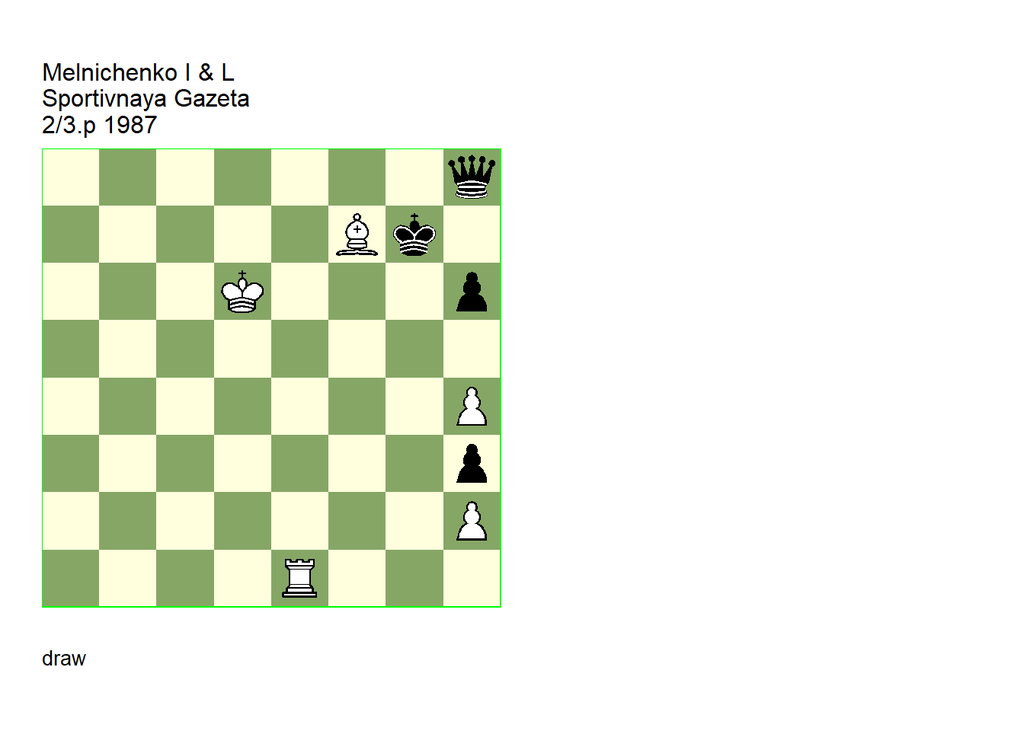

GBR: =3110.22d6g7 U2 FEN: 7q/5Bk1/3K3p/8/7P/7p/7P/4R3 w - - 0 1

(EG#07258). U2: Neuenschwander=B beatochess 14/06/2025. **1. Re8 Qh7 2. Re7 Kf8 3. Re8+ Kg7 4. Re7 Kf6 5. Re6+ Kg7** (5… Kf5 6. Bg6+) **6. Re7 Qd3+ 7. Bd5+ Kg6 8. Re6+ Kf5 9. Re5+ Kf4 10. Re4+ Kf5 11. Re5+ Kf6 12. Re6+ Kg7 13. Re7+ Kf8 14. Rf7+ Ke8 15. Re7+ Kd8 16. Rd7+** (16. Ra7!? **cook**? **BN** 16… Qg6+ 17. Be6 Qg2 18. Rd7+ Kc8 19. Ra7+ Kb8 20. Ra2 =+) **16… Kc8 17. Rc7+** (17. Ra7! **cook** **BN** 17… Qg6+ 18. Be6+ Kb8 19. Ra3) **17… Kb8 18. Rb7+ Kc8 19. Rc7+ 1/2-1/2**.

### Lewandowski =3082.31g6e7 (1986). Correction

Date: June 13, 2025

File: Lewandowski1986a.pgn

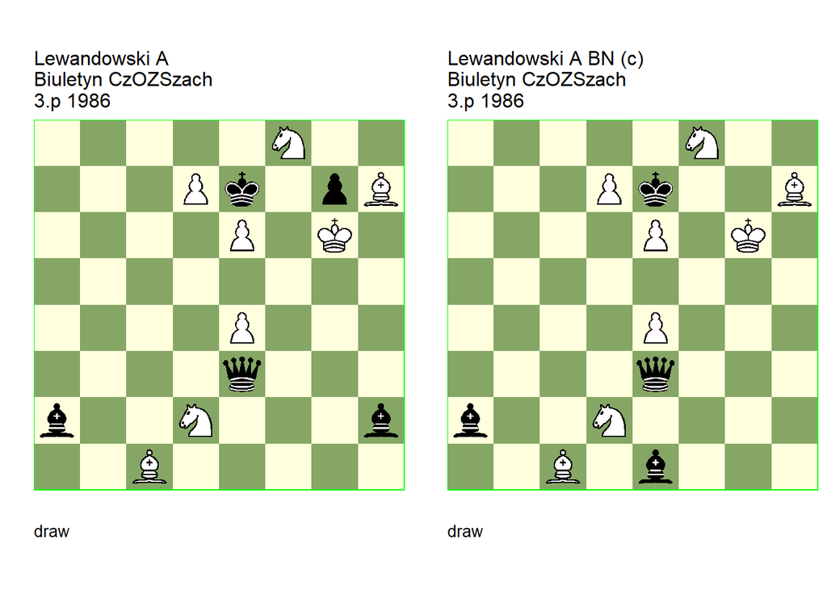

GBR: =3082.31g6e7 U3 FEN: 5N2/3Pk1pB/4P1K1/8/4P3/4q3/b2N3b/2B5 w - - 0 1

(EG#07217). U3: Garcia=M HHdbV#27392 24-9-2011. **1. Nb3** (1. Kxg7? Be5+ 2. Kg8 (2. Kg6 Qg3+ 3. Kh5 Qh3+ 4. Kg5 Bf6+ 5. Kf4 Kxf8) 2… Qg5+ 3. Ng6+ Kxe6 4. Nb3 Qd8+ 5. Nf8+ Kd6 6. Ba3+ Kc6) **1… Qxe4+ 2. Kxg7** (2. Kg5? Qg2+ 3. Kh5 Qf3+ 4. Kg5 (4. Kg6 Bb1+) 4… Qxf8) **2… Be5+** (2… Qg2+ 3. Ng6+ Kd8 4. Kh6 Qh3+ 5. Kg7 Be5+ 6. Nxe5 Qg3+ 7. Kf7 Qxe5 8. Bb2) (2… Qg4+ 3. Ng6+ Kd8 4. Bb2 Qxe6 5. Bf6+ Kxd7 6. Nf8+) (2… Qd5 3. Ng6+ Kd8 4. Bb2) (2… Qe5+! **cook** MG 3. Kg8 Qf6 4. Ba3+ Bd6 5. Bxd6+ Kxd6 6. Nd4 Kc7 7. Nf5 Bxe6+ 8. Nxe6+ Qxe6+ 9. Kg7 Kxd7) **3. Kg8 Qg4+** (3… Qd5 4. Bg5+ Bf6 5. Ng6+ Kd6 6. Bxf6 Qxe6+ 7. Kg7 Qxd7+ 8. Be7+ Kc7 9. Bg8 Bb1 (9… Qd1 10. Nc5 Bb1) 10. Nc5 Qg4 11. Bf7) **4. Ng6+** (4. Bg6? Bxb3 5. Ba3+ Kd8) **4… Kd8 5. Bg5+ Qxg5 6. e7+ Kxd7 7. e8=Q+ Kxe8 1/2-1/2**.

GBR: =3082.30g6e7 (c) FEN: 5N2/3Pk2B/4P1K1/8/4P3/4q3/b2N4/2B1b3 w - - 0 1

correction: Neuenschwander=B beatochess 13/06/2025 **1. Nb3 Qxe4+ 2. Kg7 Bc3+** ( 2… Qe5+ 3. Kg8 Qf6 4. Ba3+) **3. Kg8 Qg4+ 4. Ng6+ Kd8 5. Bg5+ Qxg5 6. e7+ Kxd7 7. e8=Q+ Kxe8 1/2-1/2**.

### Gusev +0414.01b8f8 (1986). Cook

Date: June 13, 2025

File: Gusev1986b.pgn

**2. Ne5!** cooks the second study (version.

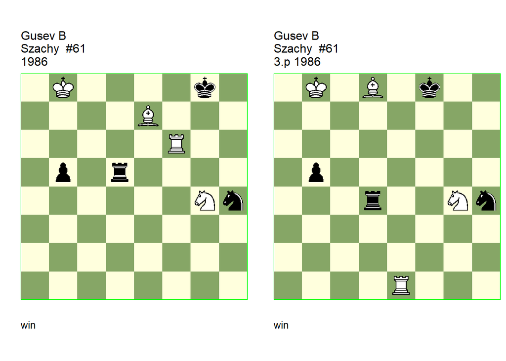

GBR: +0414.01b8g8 U1 FEN: 1K4k1/4B3/5R2/1p1r4/6Nn/8/8/8 w - - 0 1

Szachy=10(475) Szachy/10. U1: Garcia=M HHdbIV#55113 19-1-2007. **1. Rf1!** (1. Rf4? Ng6 2. Nf6+ Kf7) (1. Rc6! **cook** MG Rd4 2. Ne5 Rd5 (2… Nf5 3. Bf6 Nd6 4. Rc7 Re4 5. Re7 b4 6. Kc7) 3. Bf6 Kh7 4. Rc7+ Kh6 5. Rc3) **1… Rd4 2. Rg1 Nf3!** (2… Nf5 3. Ne5+ Kh7 4. Bf6 Rd6 5. Rh1+ Nh6 6. Ng4) **3. Rg3 Kf7! 4. Bc5!** ( 4. Nh6+? Kxe7 5. Nf5+ Ke6 6. Nxd4+ Nxd4) **4… Rc4 5. Rxf3+ Ke6 6. Re3+** (6. Rf6+? Kd5 7. Ne3+ Kxc5 8. Nxc4 bxc4) **6… Kd5 7. Re5+ Kc6 8. Nf6 Rxc5 9. Re6# 1-0**.

GBR: +0414.01b8f8 (v) U2 FEN: 1K1B1k2/8/8/1p6/3r2Nn/8/8/4R3 w - - 0 1

Szachy=10(475) Szachy/10 (EG#07205). U2: Neuenschwander=B beatochess 13/06/2025. **1. Be7+ Kg8!** (1… Kf7 2. Ne5+ Kg7 3. Rg1+) **2. Rg1** (2. Ne5! **cook** **BN** 2… Nf5 3. Rg1+ Kh7 4. Bf6 Rd6 5. Rh1+ Nh6 6. Ng4 Kg6 7. Rxh6+ Kf5 8. Ne3+ Ke4 9. Kc7) **2… Nf3!** (2… Nf5 3. Ne5+ Kh7 4. Bf6 Rd6 5. Rh1+ Nh6 6. Ng4) **3. Rg3 Kf7! 4. Bc5!** (4. Nh6+? Kxe7 5. Nf5+ Ke6 6. Nxd4+ Nxd4) **4… Rc4 5. Rxf3+ Ke6 6. Re3+!** (6. Rf6+? Kd5 7. Ne3+ Kxc5 8. Nxc4 bxc4) **6… Kd5 7. Re5+ Kc6 8. Nf6! Rxc5 9. Re6# 1-0**.

### Gurgenidze & Katsnelson =0500.23d2h1 (1987). Cook, correction

Date: June 6, 2025

File: Gurgenidze1987a.pgn

**1. Ra8** cooks the study. The same defensive idea also works later in the study.

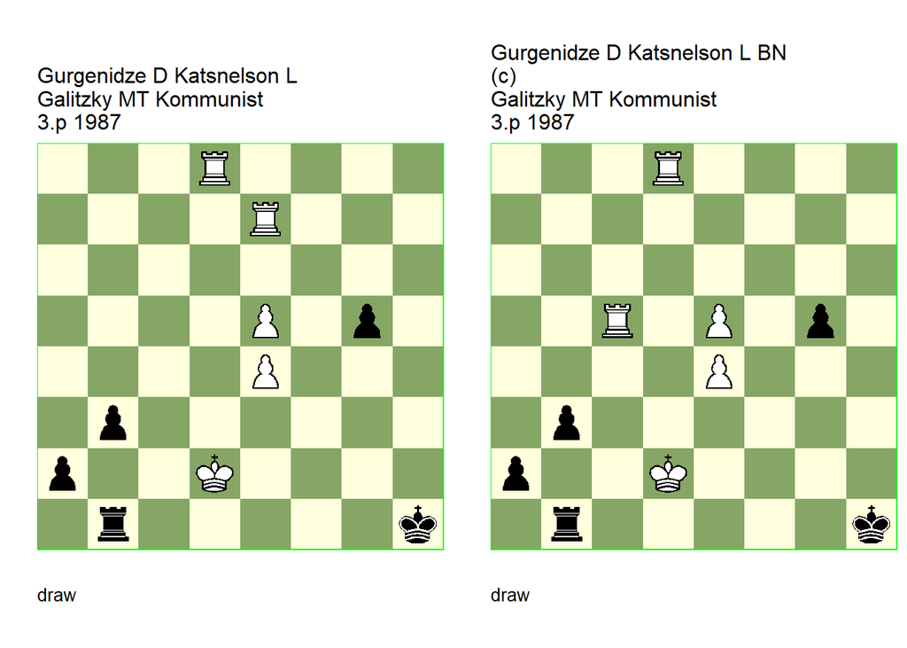

(EG#07128). U2: Neuenschwander=B beatochess 06/06/2025. **1. Ra7!** (1. Ra8? b2 2. Rxa2 (2. Rh7+! **cook** **BN** 2… Kg1 3. Rg8 Kg2 (3… Rd1+ 4. Ke2 Re1+ 5. Kf3 Rf1+ 6. Ke3) 4. Rf7 Rd1+ 5. Kc3) 2… Rd1+ 3. Ke2 b1=Q) **1… b2** (1… Rd1+ 2. Kxd1 b2 3. Rda8) **2. Rxa2 Rd1+! 3. Ke2! Re1+ 4. Kf2!** (4. Kf3? g4+ 5. Kf2 Rf1+ 6. Kg3 Rf3+ 7. Kxg4 b1=Q 8. Kxf3 Qxa2) **4… Rf1+!** (4… b1=Q 5. Rh8#) **5. Kg3! Rg1+** (5… b1=Q 6. Rh8+) **6. Kf3!** (6. Kh3? g4+) **6… g4+ 7. Kf4 Rf1+ 8. Kg5 b1=Q 9. Rh8+ Kg1 10. Rhh2! Qc1+** (10… Qxe4 11. Rag2+ Qxg2 12. Rxg2+ Kxg2 13. Kxg4) **11. Kh5! 1/2-1/2**.

GBR: =0500.23d2h1 (c) FEN: 3R4/8/8/2R1P1p1/4P3/1p6/p2K4/1r5k w - - 0 1

correction: Neuenschwander=B beatochess 06/06/2025 . **1. Ra5 b2 2. Rxa2 Rd1+ 3. Ke2 Re1+ 4. Kf2 Rf1+ 5. Kg3 Rg1+ 6. Kf3 g4+ 7. Kf4 Rf1+ 8. Kg5 b1=Q 9. Rh8+ Kg1 10. Rhh2 Qc1+ 11. Kh5** (11. Kg6 or 11… Qc6+ 12. Kg5) **1/2-1/2**.

### Caputto +3101.24h7g5 (1987). Cook

Date: June 6, 2025

File: Caputto1987a.pgn

**2. e6!** cooks the study.

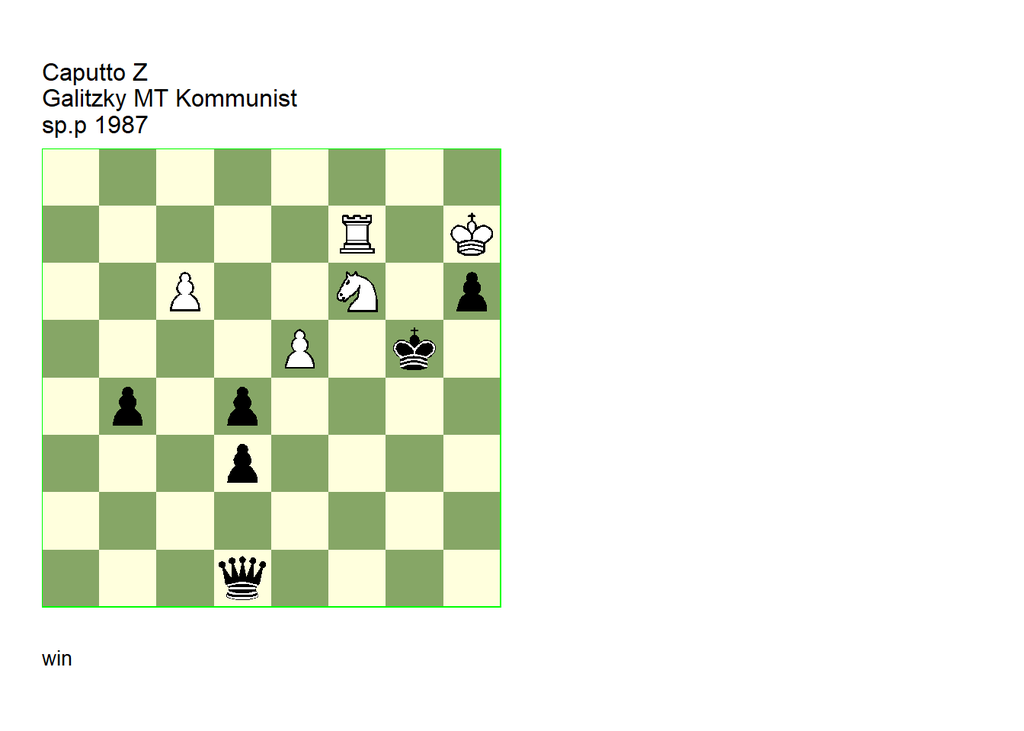

GBR: +3101.24h7g5 U2 FEN: 8/5R1K/2P2N1p/4P1k1/1p1p4/3p4/8/3q4 w - - 0 1

also Probleemblad#066 Probleemblad/3 1988 (EG#07136). U2: Neuenschwander=B beatochess 0/06/2025. **1. Ne4+ Kh5 2. Rf5+** (2. e6! **cook** **BN** 2… Qc2 3. e7 Qxc6 4. e8=Q) **2… Kh4 3. Rf4+ Kh5 4. Rg4 Qxg4 5. Nf6+ Kh4 6. Nxg4 b3 7. Nh2 b2 8. Nf3+ Kg3 9. Nd2 Kf2 10. c7 Ke1 11. c8=Q Kxd2 12. e6 b1=Q 13. e7 1-0**.

### Asaba +0043.43d8c4 (1987). Too many duals

Date: June 6, 2025

File: Asaba1987a.pgn

In addition to the minor duals at the end, White can also change the move order by playing **d5** earlier. Which makes it too many duals in my opinion.

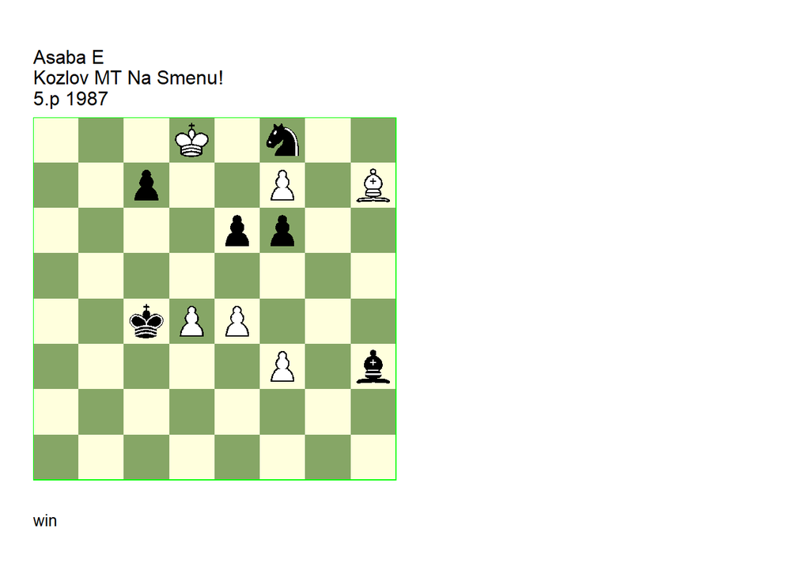

GBR: +0043.43d8c4 U2 FEN: 3K1n2/2p2P1B/4pp2/8/2kPP3/5P1b/8/8 w - - 0 1

(EG#07142). (U2): Haworth=G Bleicher=E HHdbIV#55635 4-12-2009. U2: Neuenschwander=B beatochess 06/06/2025. **1. Bg8 Bg2 2. Ke8 Bxf3 3. Kxf8** (3. d5 **dual** **BN** 3… exd5 4. Kxf8 Bh5 5. Ke7) **3… Bh5 4. d5 exd5 5. Ke7 Bxf7 6. Bxf7 Kd4 7. exd5 f5 8. Ke6** (8. Kd7! minor, **dual** GH/EB ) (8. Be6! minor, **dual** GH/EB ) **1-0**.